# Correlation Using R (with RStudio)

Correlation Using R (with RStudio)

## What is Correlation and when to use it?

Correlation is a measure of the strength of the relationship between two variables.  
It is measured using a number called the correlation coefficient which lies between -1 and +1. If the correlation is positive, this means that one variable increases as the other increases. If the correlation is negative, one variable decreases as the other variable increases. Larger values closer to +1 or -1 indicate a stronger relationship. Values nearer to zero indicate weaker or even no relationship.The most used measures are Pearson’s correlation coefficient and Spearman’s correlation coefficient. For help on “What test do I need” go to the sigma website [statistics resources page](https://libguides.coventry.ac.uk/c.php?g=712076&p=5146769).

Pearson’s correlation measures the strength of the linear (i.e. straight-line) relationship, whereas Spearman’s correlation simply measures the strength of a general monotonic relationship which can be non-linear (monotonic means always increasing or always decreasing).

- The variables used to calculate a correlation coefficient need to be scale or ordinal. Correlation is not appropriate if any of the variables are nominal.
- Pearson’s correlation is appropriate if both variables are scale.
- Spearman’s correlation can be used for any combination of scale and ordinal variables (i.e. both can be scale or both ordinal or one of each).

If one or both variables are scale, you should also obtain a scatter plot to visualize the relationship between them. We can also conduct a test on the correlation coefficient – see later.

## Example

A student wanted to explore the relationship between knowledge about calcium and calcium intake, among sports science students. The data shown below can be downloaded from [HERE](https://livecoventryac.sharepoint.com/:x:/s/all.documents/EQQlQpGnQCZLhHQj9u-Ud2MBuT8YnuENMssgJMqykwGBHA?e=Z1i3tS) in a .csv file called “Calcium”.

Table 1: Calcium Data in Excel

[figure not shown]

## Using R with RStudio

### Step 1: Importing the data into R.

To get started with the analysis, first, bring the dataset into RStudio. To do this you can either run a read.csv() function if you know how to do this or alternatively you can follow the following steps using the menus:

From the **File** menu select **Import Dataset** then **From Text(base)**:

[figure not shown]

From the pop-up window navigate to the folder **where you have saved the dataset**, then once the file was selected click **“Open”**:

[figure not shown]

At the next dialogue box (see below), in the upper left corner in the **“Name”** field, amend the name of your dataset if you wish, in this example we named it as **“calcium”**.

We should also make sure the **Heading** option below is set to **Yes** (otherwise the data will all be read in as text):

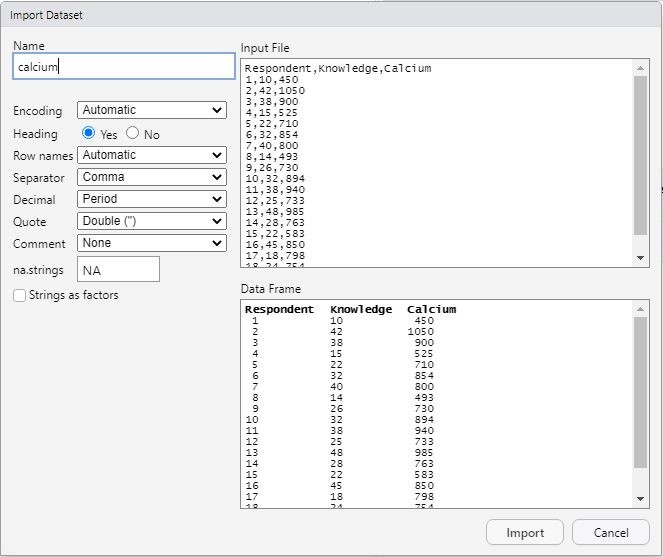

Finally, click on **“Import”** to complete the process. This imports the data set and is listed in the **“Environment”** in the top right of your RStudio screen as follows:

[figure not shown]

### Step 2: Initial data Vizualisation

Since **both variables are scale**, we will use **Pearson’s** correlation, but first we should examine the relationship using a scatter plot.

This snippet of code will allow us to create the scatter plot of this data:

```r
plot(calcium$Knowledge, calcium$Calcium,
     xlab = "Knowledge Score", ylab = "Calcium Intake",
     main = "Calcium Intake vs Knowledge Score")
abline(lm(Calcium ~ Knowledge, data = calcium), col = "red")
```

Once you run the previous code, you should have the following graph:

Figure 1: Scatter plot of Calcium intake and knowledge.

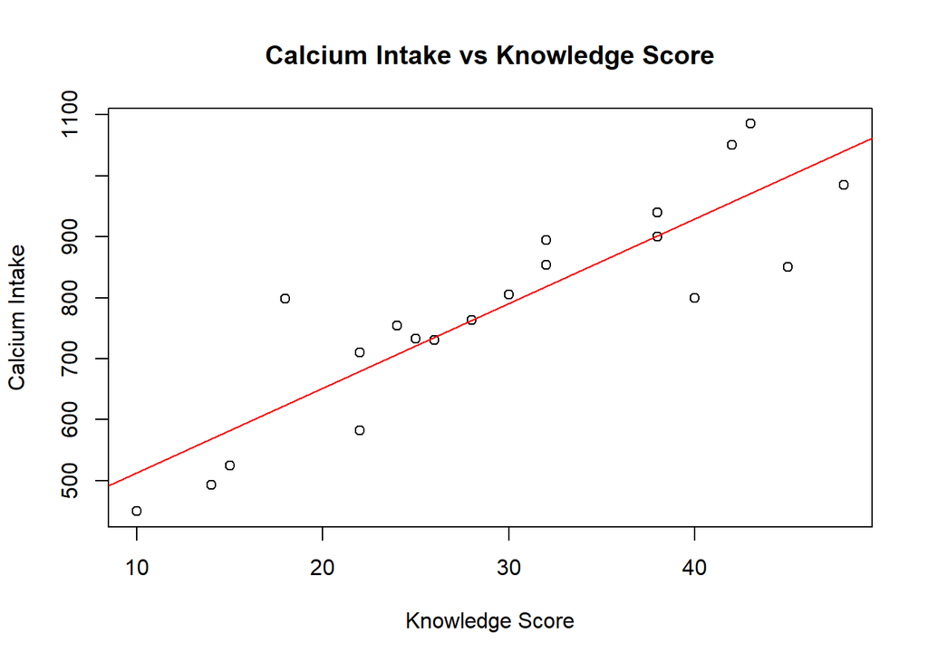

In the plot, the points follow an increasing pattern and seem to be reasonably close to an underlying straight line. This suggests there is a strong relationship between the two variables and also that it looks reasonably linear.

To correlation coefficient can be obtained in R, using the following code:

```r
correlation <- cor.test(calcium$Knowledge, calcium$Calcium, method='pearson')
correlation
```

Note that if required, we could have opted for the Spearman correlation if we had ordinal data.

## Examining the Output

Running above code should produce this output:

```
##
##  Pearson's product-moment correlation
##
## data:  calcium$Knowledge and calcium$Calcium
## t = 7.951, df = 18, p-value = 2.675e-07
## alternative hypothesis: true correlation is not equal to 0
## 95 percent confidence interval:
##  0.7213682 0.9527909
## sample estimates:
##       cor
## 0.8822551
```

The Pearson correlation coefficient is 0.8822551. We could report this as r=0.88 as two decimal places is sufficient. This is indicative of a strong relationship, as we saw earlier through the scatter plot. It is also positive which indicates that calcium intake increases as knowledge of calcium increases and vice-versa.

A commonly used interpretation is based on benchmarks suggested by Cohen (1992). Here correlation strengths are classified as in the table below. Note our value of 0.88 falls in the strong category of 0.5 to 0.9.

| Correlation Coefficient Value | Interpretation |
| --- | --- |
| -0.3 to +0.3 | Weak |
| -0.5 to -0.3 or 0.3 to 0.5 | Moderate |
| -0.9 to -0.5 or 0.5 to 0.9 | Strong |
| -0.9 to -1 or 0.9 to 1 | Very Strong |

Extracted from Cohen, L.(1992). Power Primer. Psychological Bulletin, 112(1) 155-159

The table in the earlier correlation test output includes a number labelled as the p-value reported as 2.675e-07 by R, which is a value smaller than 0.001. This p-value is used to explore the research question:

*Is there a true relationship between the intake of calcium and knowledge about calcium?*

This can be tested formally using the hypotheses:  
H0: There is no correlation between calcium intake and knowledge about calcium (equivalent to saying r = 0)  
H1: There is some correlation between calcium intake and knowledge about calcium (equivalent to saying r not = 0).

Since our p-value is reported as p is less than 0.001 this means it is below the usual level of 0.05 used to test such hypotheses and so we can reject H0 and conclude there is evidence of a true correlation in the wider population of Sports Science students. The point here is that whilst our correlation coefficient of 0.88 indicates a strong relationship, this is true for our sample of 20 participants; but can we use this as evidence to infer that a relationship truly exists between knowledge and intake of calcium among ALL Sports Science students (not just in our sample)? In our case the test we did above says yes, we can.

### Reporting the Results

We could report the results as:

*“Among Sports Science students, there is evidence that knowledge about calcium is related to calcium intake (p less than 0.001). Greater knowledge about calcium is associated with increase calcium intake and the correlation coefficient indicated a strong linear relationship (r=0.88)”*

Note how we avoid suggesting that greater knowledge CAUSES increased calcium intake as correlation cannot be used to infer a cause-and-effect relationship.

For more resources, see sigma.coventry.ac.uk Adapted from material developed by Coventry University